# Assignment L09: Image Identification with an ANN

**Author: Preston Went**  
**Course: DATASCI 420**  
**DATE (MM/DD/YYYY): 03/11/2021**

# Table of Contents

## Introduction

In this assignment, I will use an artificial neural network (ANN) to identify objects in an image.

As always, I will import all necessary libraries before starting.

```python
# Data manipulation
import pandas as pd
import numpy as np

# Data visualization
import matplotlib.pyplot as plt
%matplotlib inline
import seaborn as sns; sns.set();

# Modeling
import tensorflow as tf
from tensorflow import keras

# Data preprocessing
from keras.utils import to_categorical

# Model evaluation
from sklearn.metrics import average_precision_score
from sklearn.metrics import roc_auc_score
from sklearn.metrics import classification_report

# Set our random seed
RAND_SEED = 5743829
np.random.seed(RAND_SEED)
```

## Importing and Preparing the Data

We must load the data before we can do anything with it, so let us do that now. Our dataset is the CIFAR10 dataset. It consists of 50,000 training examples and 10,000 testing examples. Each example is a 32 by 32 image with 3 channels, each ranging in value from 0 to 255. The images each contain one of the following ten objects: airplane, automobile, bird, cat, deer, dog, frog, horse, ship, or truck.

```python
# Load the CIFAR10 dataset
data = keras.datasets.cifar10
(X_train, y_train), (X_test, y_test) = data.load_data()
```

We should divide the channel values by 255 to place them in the range of 0 to 1.

```python
# Scale the data
X_train = X_train / 255.
X_test = X_test / 255.
```

## Exploring the Data

Let us take a look at the data.

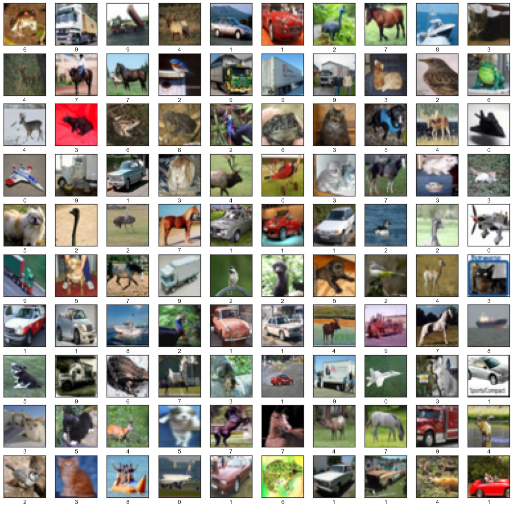

```python
sns.set_style('white') # Set the plotting style
ax = plt.figure(figsize=(18, 18)) # Create the axes

# Plot the images
for i in range(100):
    plt.subplot(10, 10,i+1)
    plt.xticks([])
    plt.yticks([])
    plt.imshow(X_train[i])
    plt.xlabel(y_train[i][0])
```

```python
# Make certain the label vectors are in the right format
y_train = to_categorical(y_train)
y_test = to_categorical(y_test)
```

## The Initial Model

We will be using a simple model to start. It will flatten our inputs, put them through a single hidden dense layer with 30 nodes, and then output. We should also set our label vectors to the right format.

```python
# Construct the model
nn_mdl = keras.Sequential([
    keras.layers.Flatten(input_shape=(32, 32, 3)),
    keras.layers.Dense(30, activation=tf.nn.sigmoid),
    keras.layers.Dense(10, activation=tf.nn.sigmoid)
])
```

Now we can train our model on the training set. We will use the categorical cross entropy as our loss function, and ADAM as our training method.

```python
# Define the training and evaluation process
nn_mdl.compile(optimizer='adam',
               loss='categorical_crossentropy',
               metrics=['accuracy'])
```

```python
# Train the neural network
nn_mdl.fit(X_train, y_train, epochs=10)
```

```
Train on 50000 samples
```

```
<tensorflow.python.keras.callbacks.History at 0x27daffa4308>
```

```python
# Get predictions on the testing set
y_pred_proba = nn_mdl.predict(X_test)
y_pred = np.zeros_like(y_pred_proba)
y_pred[np.arange(len(y_pred_proba)), y_pred_proba.argmax(1)] = 1

# Get and print the evaluation metrics
print('Avg. Precision: {:.2f}'.format(average_precision_score(y_test, y_pred_proba)))
print('AUC-ROC: {:.2f}'.format(roc_auc_score(y_test, y_pred_proba)))
print(classification_report(y_test, y_pred, zero_division=1))
```

```
Avg. Precision: 0.36
AUC-ROC: 0.81
              precision    recall  f1-score   support

           0       0.43      0.55      0.48      1000
           1       0.57      0.46      0.51      1000
           2       0.35      0.21      0.26      1000
           3       0.28      0.33      0.30      1000
           4       0.35      0.36      0.36      1000
           5       0.46      0.18      0.26      1000
           6       0.41      0.51      0.45      1000
           7       0.46      0.47      0.46      1000
           8       0.50      0.56      0.53      1000
           9       0.42      0.56      0.48      1000

   micro avg       0.42      0.42      0.42     10000
   macro avg       0.42      0.42      0.41     10000
weighted avg       0.42      0.42      0.41     10000
 samples avg       0.42      0.42      0.42     10000
```

The results are substantially better than random, but still leave plenty of room for improvement.

## Improving the Model

Let us try to improve the model. I will do this by converting it to a convolutional neural network. Features will be extracted with two convolutional layers, each followed by a maximum pooling layer. This will then feed into a simple multilayer perceptron after being flattened - two hidden layers with 100 nodes each.

```python
# Construct the model
nn_mdl = keras.Sequential([
    keras.layers.Conv2D(filters=32,
                        kernel_size=(3, 3),
                        strides=(1, 1),
                        padding='same',
                        activation=tf.nn.relu,
                        input_shape=(32, 32, 3)),
    keras.layers.MaxPooling2D(pool_size=(2, 2),
                              strides=(2, 2)),
    keras.layers.Conv2D(filters=32,
                        kernel_size=(3, 3),
                        strides=(1, 1),
                        padding='same',
                        activation=tf.nn.relu,
                        input_shape=(32, 32, 3)),
    keras.layers.MaxPooling2D(pool_size=(2, 2),
                              strides=(2, 2)),
    keras.layers.Flatten(input_shape=(32, 32, 3)),
    keras.layers.Dense(100, activation=tf.nn.relu),
    keras.layers.Dense(100, activation=tf.nn.relu),
    keras.layers.Dense(10, activation=tf.nn.softmax)
])
```

Let us train this model on our training set, using the same process as the original.

```python
# Define the training and evaluation process
nn_mdl.compile(optimizer='adam',
               loss='categorical_crossentropy',
               metrics=['accuracy'])
```

```python
# Train the neural network
nn_mdl.fit(X_train, y_train, epochs=10)
```

```
Train on 50000 samples
```

```
<tensorflow.python.keras.callbacks.History at 0x27fb4d03d88>
```

```python
# Get predictions on the testing set
y_pred_proba = nn_mdl.predict(X_test)
y_pred = np.zeros_like(y_pred_proba)
y_pred[np.arange(len(y_pred_proba)), y_pred_proba.argmax(1)] = 1

# Get and print the evaluation metrics
print('Avg. Precision: {:.2f}'.format(average_precision_score(y_test, y_pred_proba)))
print('AUC-ROC: {:.2f}'.format(roc_auc_score(y_test, y_pred_proba)))
print(classification_report(y_test, y_pred, zero_division=1))
```

```
Avg. Precision: 0.77
AUC-ROC: 0.95
              precision    recall  f1-score   support

           0       0.73      0.74      0.74      1000
           1       0.80      0.77      0.78      1000
           2       0.59      0.58      0.59      1000
           3       0.56      0.35      0.43      1000
           4       0.72      0.58      0.64      1000
           5       0.48      0.74      0.58      1000
           6       0.78      0.75      0.76      1000
           7       0.77      0.73      0.75      1000
           8       0.86      0.76      0.80      1000
           9       0.67      0.86      0.75      1000

   micro avg       0.69      0.69      0.69     10000
   macro avg       0.70      0.69      0.68     10000
weighted avg       0.70      0.69      0.68     10000
 samples avg       0.69      0.69      0.69     10000
```

## Conclusions

We built and tested two neural networks on the CIFAR10 dataset. The first was a single layer perceptron, and the second a convolutional neural network. What was not shown here was the dozen or so intermediary networks I constructed and tested. Here is what I learned from this process:

- Deeper neural networks tend to perform better, but have a greater propensity for overfitting.
- Adding more layers or more nodes is no substitute for properly structuring the network so that it can extract better features. The leap in performance I saw between a large multilayer perceptron and a smaller convolutional neural network was massive.
- Neural networks are not nearly as intimidating as everyone makes them seem. As with most advanced mathematics, it's less magic and more trial and error, instinct, and compute time.

This was a particularly fun assignment.